# Raisin

2022-10-06

**Sources**

https://archive.ics.uci.edu/ml/datasets/Raisin+Dataset

**About**

Images of Kecimen and Besni raisin varieties grown in Turkey were obtained with CVS. A total of 900 raisin grains were used, including 450 pieces from both varieties. These images were subjected to various stages of pre-processing and 7 morphological features were extracted. These features have been classified using three different artificial intelligence techniques.

**Attribute Information:**

1. ar: Area gives the number of pixels within the boundaries of the raisin.
2. peri: Perimeter measures the environment by calculating the distance between the boundaries of the raisin and the pixels around it.
3. majorAL: Major Axis Length gives the length of the main axis, which is the longest line that can be drawn on the raisin.
4. minorAL: Minor Axis Length gives the length of the small axis, which is the shortest line that can be drawn on the raisin.
5. ecc: Eccentricity gives a measure of the eccentricity of the ellipse, which has the same moments as raisins.
6. conArea: Convex Area gives the number of pixels of the smallest convex shell of the region formed by the raisin.
7. extent: Gives the ratio of the region formed by the raisin to the total pixels in the bounding box.
8. class: Kecimen and Besni raisin.

**Contributors:**

Ilkay CINAR, Faculty of Technology, Selcuk University, Konya, TURKEY. ORCID ID : 0000-0003-0611-3316 ilkay.cinar ‘@’ selcuk.edu.tr

Murat KOKLU, Faculty of Technology, Selcuk University, Konya, TURKEY. ORCID ID : 0000-0002-2737-2360 mkoklu ‘@’ selcuk.edu.tr

Sakir TASDEMIR, Faculty of Technology, Selcuk University, Konya, TURKEY. ORCID ID : 0000-0002-2433-246X stasdemir ‘@’ selcuk.edu.tr

**Citation Request:**

CINAR I., KOKLU M. and TASDEMIR S., (2020), Classification of Raisin Grains Using Machine Vision and Artificial Intelligence Methods. Gazi Journal of Engineering Sciences, vol. 6, no. 3, pp. 200-209, December, 2020. DOI: https://doi.org/10.30855/gmbd.2020.03.03

## Attributes Details

```r
library(readxl)
library(moments)

raisin <- read_xlsx("Raisin_Dataset.xlsx")
options(digits = 2)
summary(raisin)
```

```
##        ar            majorAL       minorAL         ecc          conArea
##  Min.   : 25387   Min.   :226   Min.   :144   Min.   :0.35   Min.   : 26139
##  1st Qu.: 59348   1st Qu.:345   1st Qu.:219   1st Qu.:0.74   1st Qu.: 61513
##  Median : 78902   Median :408   Median :248   Median :0.80   Median : 81651
##  Mean   : 87804   Mean   :431   Mean   :254   Mean   :0.78   Mean   : 91186
##  3rd Qu.:105028   3rd Qu.:494   3rd Qu.:280   3rd Qu.:0.84   3rd Qu.:108376
##  Max.   :235047   Max.   :997   Max.   :492   Max.   :0.96   Max.   :278217
##      extent          peri         class
##  Min.   :0.38   Min.   : 619   Length:900
##  1st Qu.:0.67   1st Qu.: 966   Class :character
##  Median :0.71   Median :1120   Mode  :character
##  Mean   :0.70   Mean   :1166
##  3rd Qu.:0.73   3rd Qu.:1308
##  Max.   :0.84   Max.   :2698
```

**1) ar**

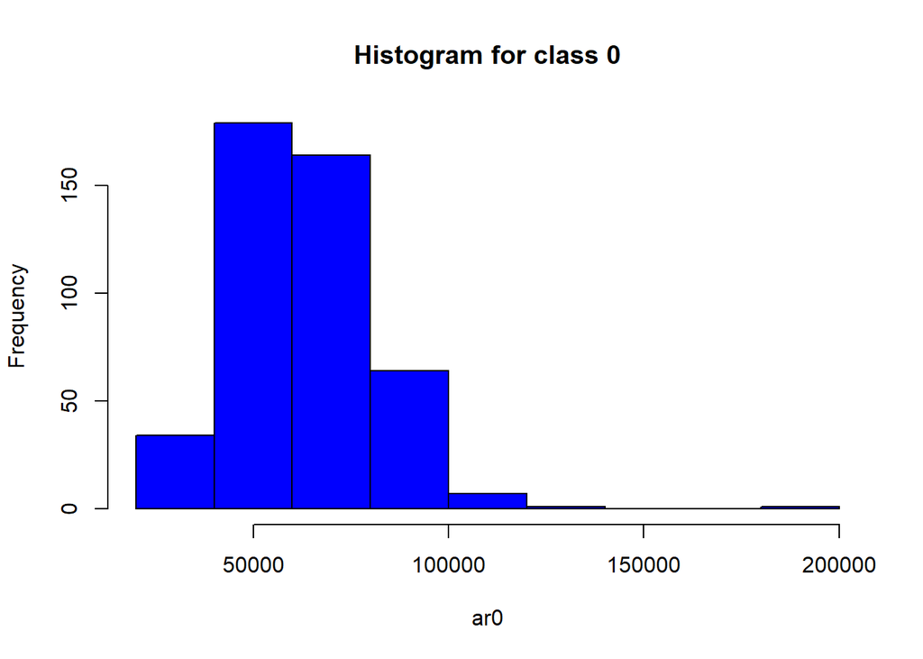

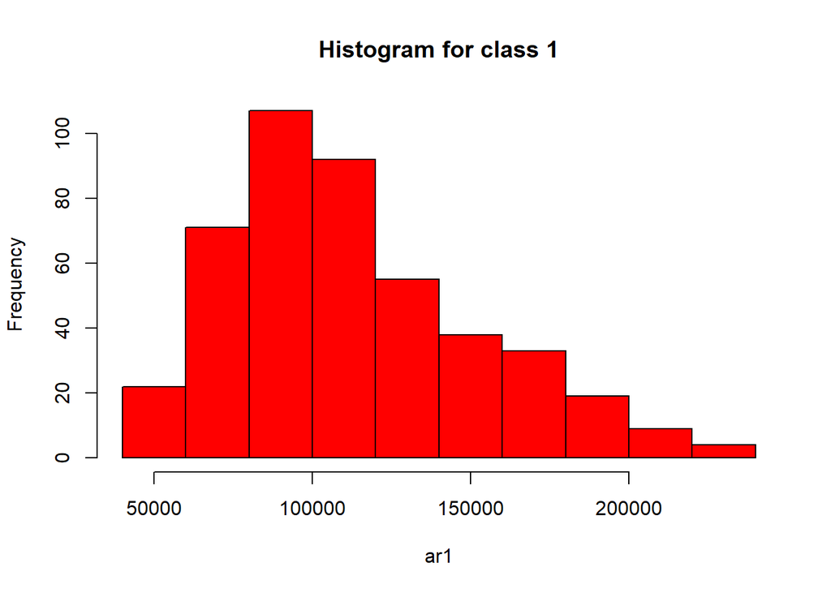

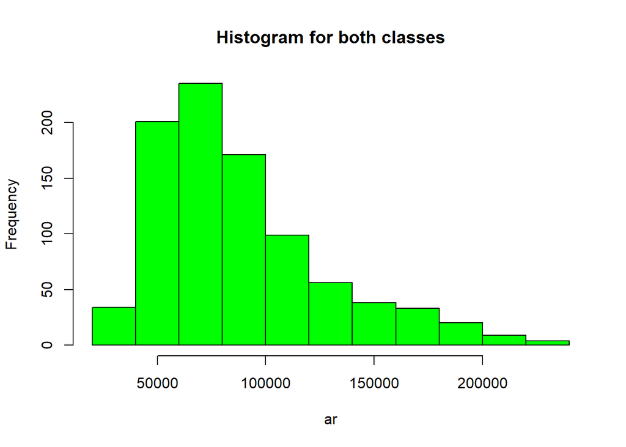

```r
class0 <- subset(raisin,class=='Kecimen')
ar0<-class0$ar
hist(ar0, main= "Histogram for class 0", col = "blue")
class1<-subset(raisin,class=='Besni')
ar1<-class1$ar
hist(ar1, main= "Histogram for class 1", col = "red")
ar<-raisin$ar
hist(ar, main= "Histogram for both classes", col = "green")
```

**2) peri**

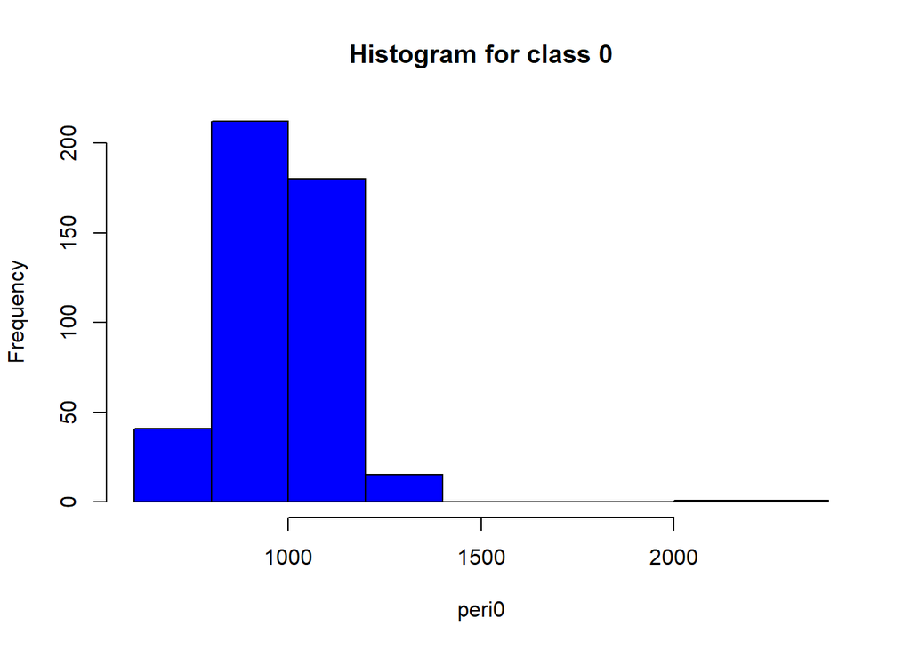

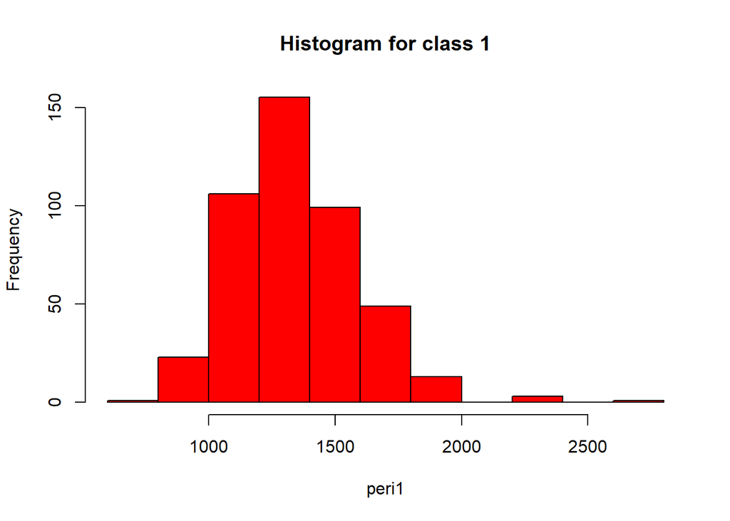

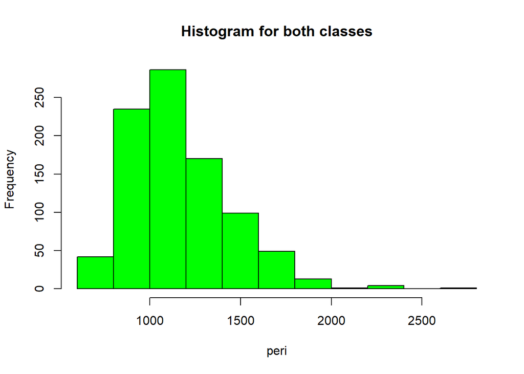

```r
class0 <- subset(raisin,class=='Kecimen')
peri0<-class0$peri
hist(peri0, main= "Histogram for class 0", col = "blue")
class1<-subset(raisin,class=='Besni')
peri1<-class1$peri
hist(peri1, main= "Histogram for class 1", col = "red")
peri<-raisin$peri
hist(peri, main= "Histogram for both classes", col = "green")
```

**3) majorAL**

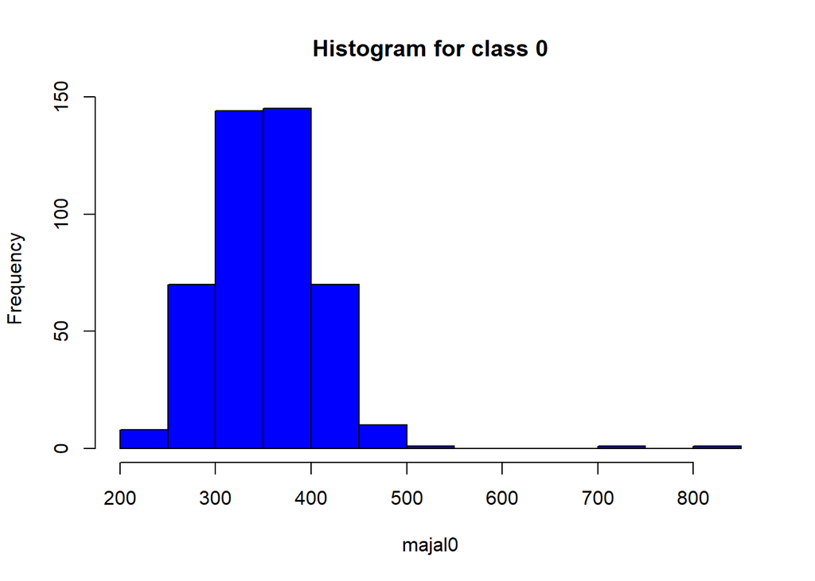

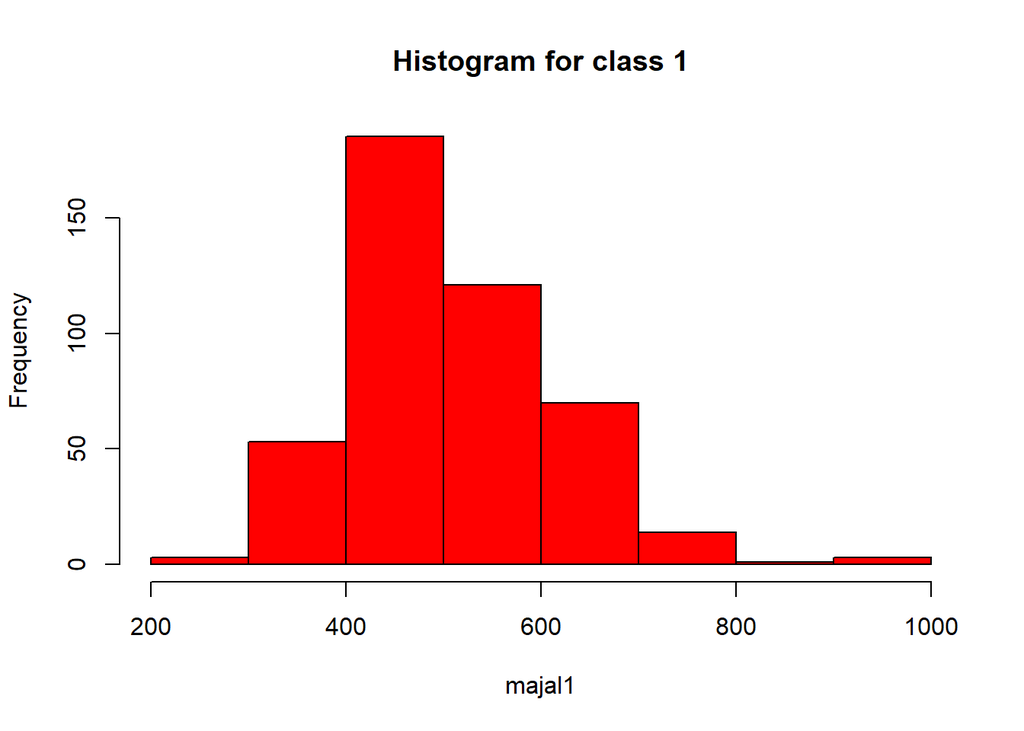

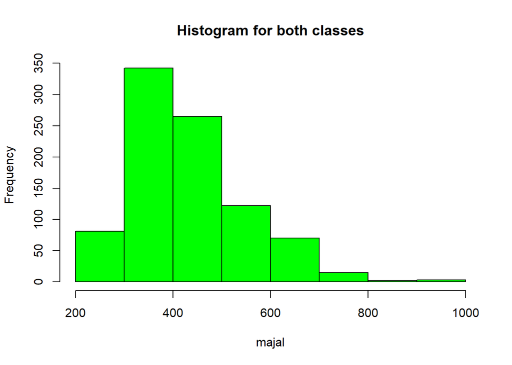

```r
class0 <- subset(raisin,class=='Kecimen')
majal0<-class0$majorAL
hist(majal0, main= "Histogram for class 0", col = "blue")
class1<-subset(raisin,class=='Besni')
majal1<-class1$majorAL
hist(majal1, main= "Histogram for class 1", col = "red")
majal<-raisin$majorAL
hist(majal, main= "Histogram for both classes", col = "green")
```

**4) minorAL**

[figure not shown]

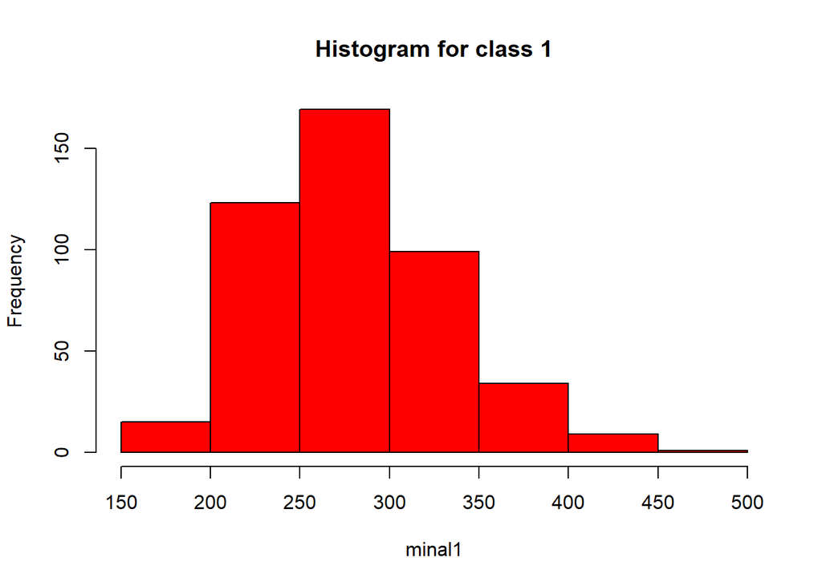

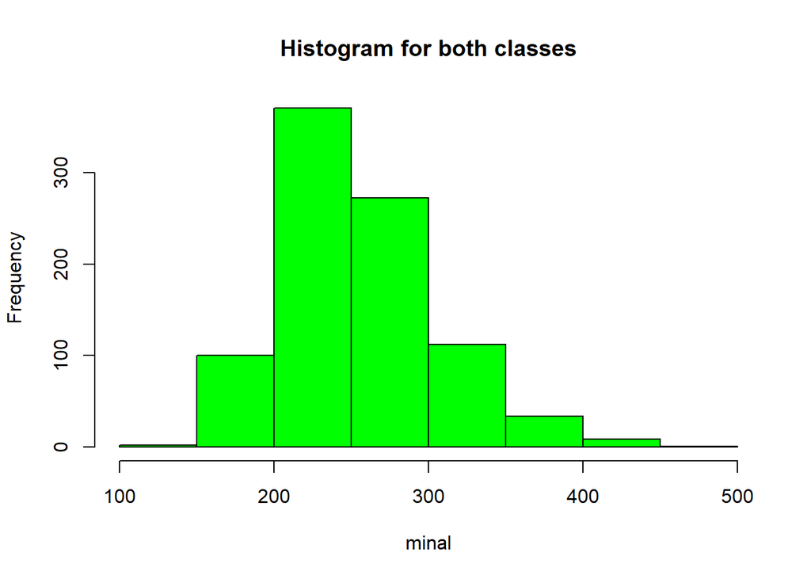

```r
class0 <- subset(raisin,class=='Kecimen')
minal0<-class0$minorAL
hist(ar0, main= "Histogram for class 0", col = "blue")
class1<-subset(raisin,class=='Besni')
minal1<-class1$minorAL
hist(minal1, main= "Histogram for class 1", col = "red")
minal<-raisin$minorAL
hist(minal, main= "Histogram for both classes", col = "green")
```

**5) ecc**

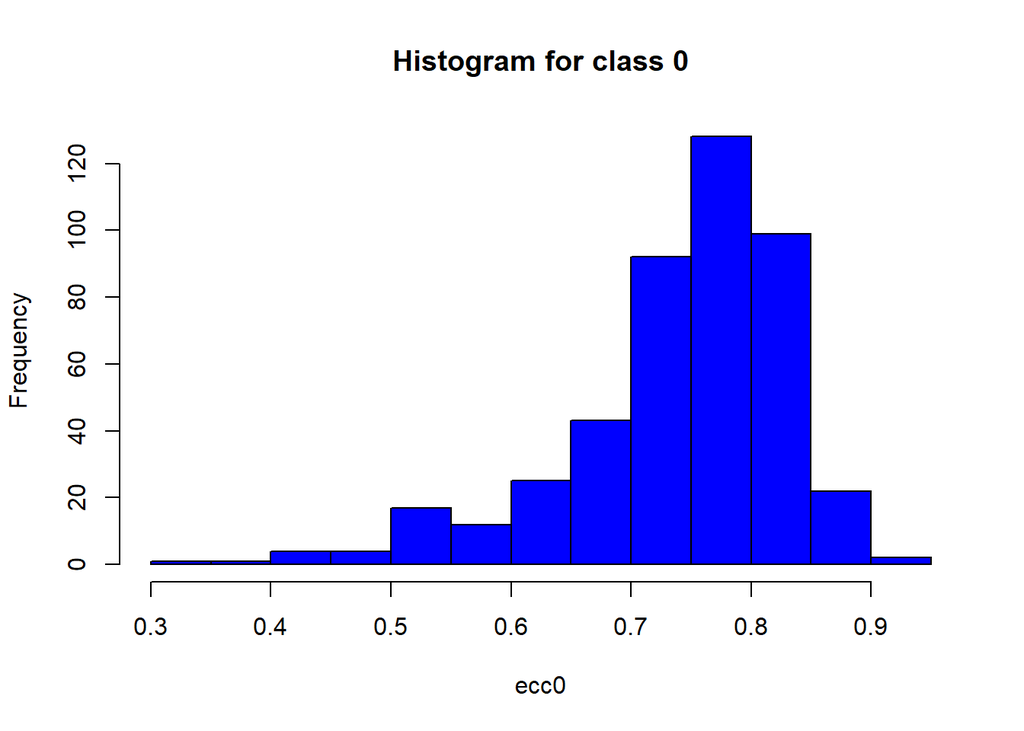

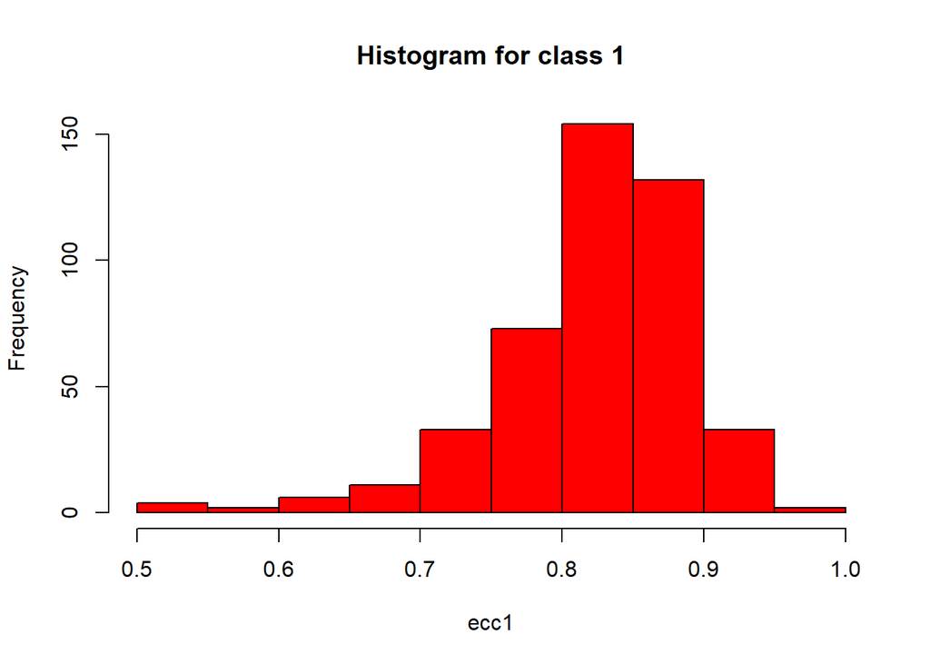

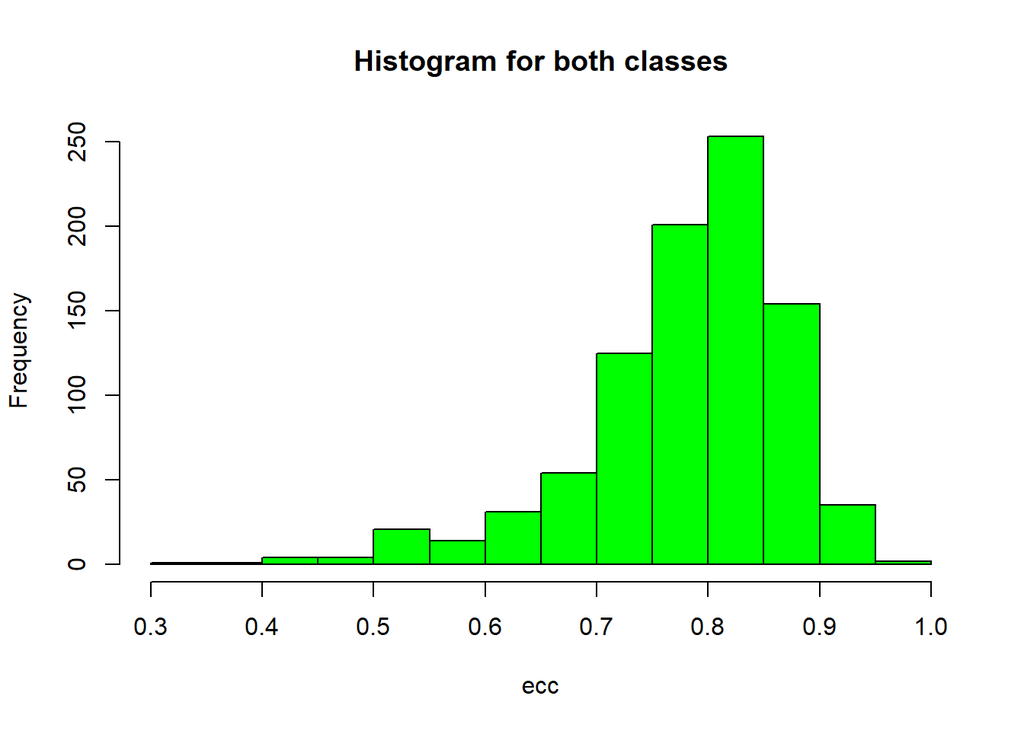

```r
class0 <- subset(raisin,class=='Kecimen')
ecc0<-class0$ecc
hist(ecc0, main= "Histogram for class 0", col = "blue")
class1<-subset(raisin,class=='Besni')
ecc1<-class1$ecc
hist(ecc1, main= "Histogram for class 1", col = "red")
ecc<-raisin$ecc
hist(ecc, main= "Histogram for both classes", col = "green")
```

**6) conArea**

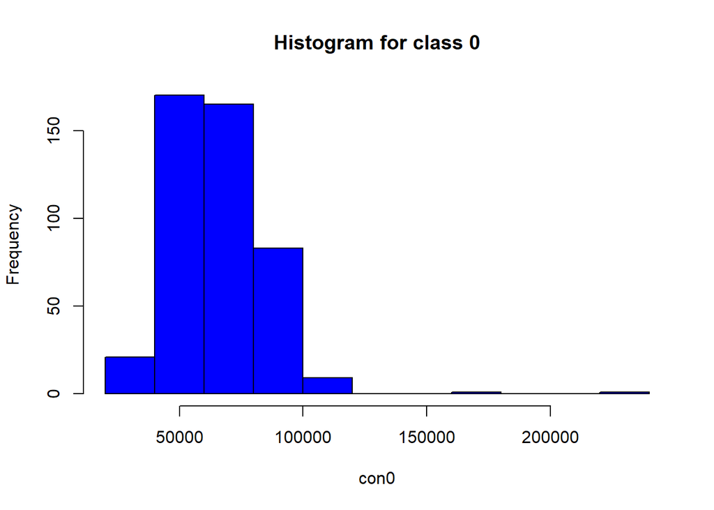

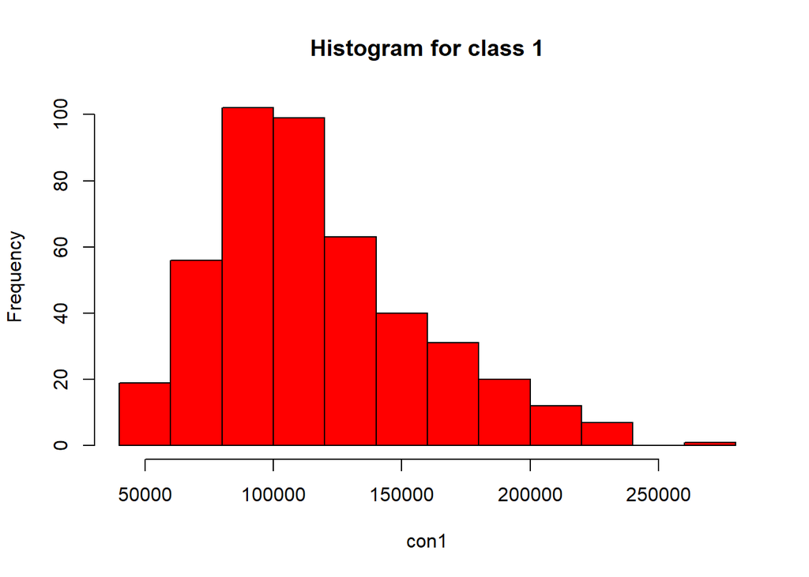

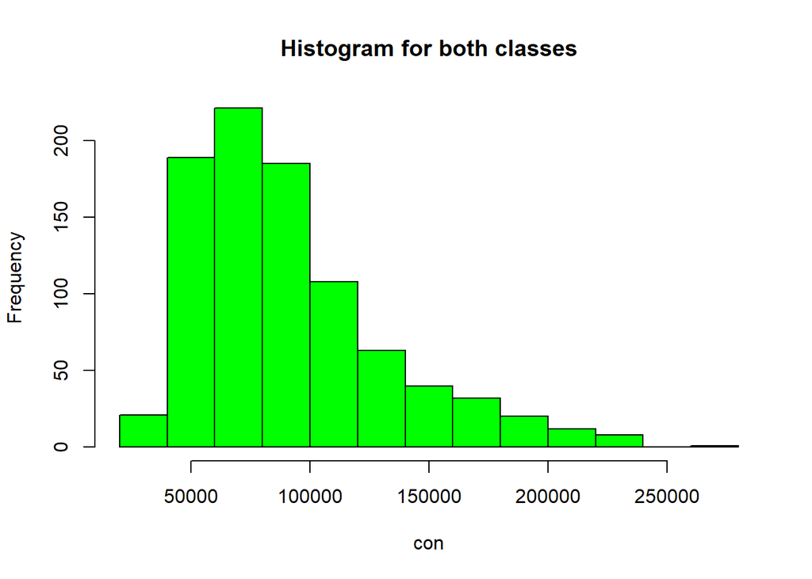

```r
class0 <- subset(raisin,class=='Kecimen')
con0<-class0$conArea
hist(con0, main= "Histogram for class 0", col = "blue")
class1<-subset(raisin,class=='Besni')
con1<-class1$conArea
hist(con1, main= "Histogram for class 1", col = "red")
con<-raisin$conArea
hist(con, main= "Histogram for both classes", col = "green")
```

**7) extent**

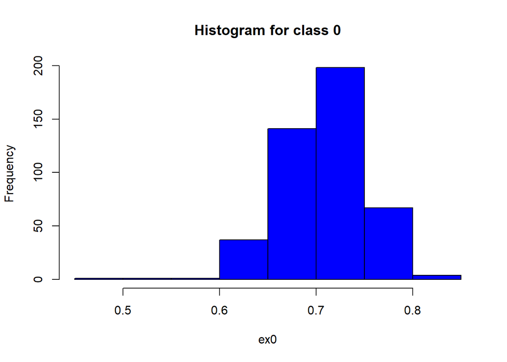

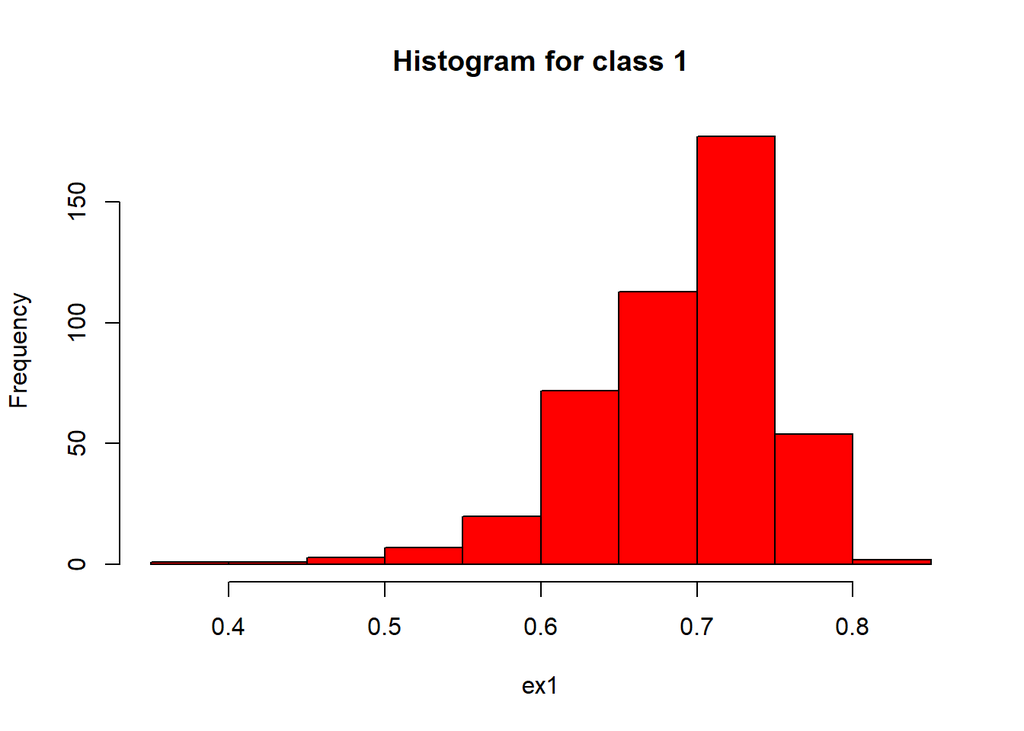

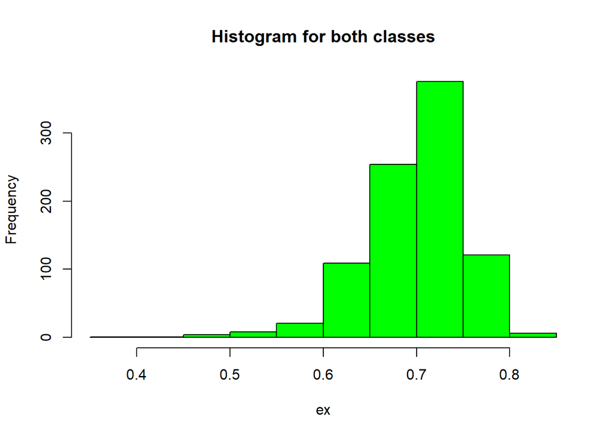

```r
class0 <- subset(raisin,class=='Kecimen')
ex0<-class0$extent
hist(ex0, main= "Histogram for class 0", col = "blue")
class1<-subset(raisin,class=='Besni')
ex1<-class1$extent
hist(ex1, main= "Histogram for class 1", col = "red")
ex<-raisin$extent
hist(ex, main= "Histogram for both classes", col = "green")
```

## Correlation Matrix

**Class 0**

```r
options(digits = 2)
co0<-subset(raisin,class=='Kecimen')
cor(co0[-8])
```

```
##              ar majorAL minorAL    ecc conArea  extent  peri
## ar       1.0000    0.90    0.87  0.075   0.992 -0.0027  0.96
## majorAL  0.8978    1.00    0.58  0.457   0.916 -0.2009  0.95
## minorAL  0.8727    0.58    1.00 -0.384   0.844  0.2045  0.76
## ecc      0.0748    0.46   -0.38  1.000   0.095 -0.3712  0.21
## conArea  0.9918    0.92    0.84  0.095   1.000 -0.0589  0.98
## extent  -0.0027   -0.20    0.20 -0.371  -0.059  1.0000 -0.16
## peri     0.9560    0.95    0.76  0.212   0.978 -0.1578  1.00
```

```r
cov(co0[-8])
```

```
##               ar  majorAL  minorAL      ecc  conArea   extent     peri
## ar       3.1e+08  9.5e+05 526930.1 122.5444  3.3e+08  -2.0758  2.5e+06
## majorAL  9.5e+05  3.6e+03   1184.5   2.5173  1.0e+06  -0.5202  8.5e+03
## minorAL  5.3e+05  1.2e+03   1160.0  -1.2070  5.5e+05   0.3026  3.9e+03
## ecc      1.2e+02  2.5e+00     -1.2   0.0085  1.7e+02  -0.0015  2.9e+00
## conArea  3.3e+08  1.0e+06 546132.8 167.6235  3.6e+08 -48.6447  2.8e+06
## extent  -2.1e+00 -5.2e-01      0.3  -0.0015 -4.9e+01   0.0019 -1.0e+00
## peri     2.5e+06  8.5e+03   3866.0   2.9419  2.8e+06  -1.0307  2.3e+04
```

```r
det(cor(co0[-8]))
```

```
## [1] 4.4e-08
```

```r
det(cov(co0[-8]))
```

```
## [1] 7.5e+15
```

```r
eigen(cor(co0[-8]))
```

```
## eigen() decomposition
## $values
## [1] 4.5347 1.6969 0.6857 0.0584 0.0155 0.0076 0.0012
##
## $vectors
##        [,1]   [,2]   [,3]  [,4]   [,5]   [,6]    [,7]
## [1,] -0.465 -0.073  0.021 -0.27 -0.473  0.098  0.6876
## [2,] -0.440  0.234  0.171  0.32 -0.281 -0.693 -0.2464
## [3,] -0.388 -0.398 -0.181 -0.62  0.365 -0.279 -0.2505
## [4,] -0.069  0.680  0.514 -0.46  0.202  0.122 -0.0482
## [5,] -0.468 -0.035 -0.020  0.11 -0.262  0.631 -0.5494
## [6,]  0.039 -0.559  0.820  0.10  0.034  0.023  0.0031
## [7,] -0.463  0.073 -0.019  0.45  0.674  0.140  0.3155
```

```r
eigen(cov(co0[-8]))
```

```
## eigen() decomposition
## $values
## [1] 6.7e+08 2.7e+06 1.2e+03 2.6e+02 1.3e+01 1.3e-03 7.9e-04
##
## $vectors
##          [,1]     [,2]    [,3]     [,4]    [,5]     [,6]     [,7]
## [1,]  6.8e-01  7.3e-01  0.0081  2.0e-03  0.0031  4.0e-06 -1.4e-05
## [2,]  2.1e-03 -5.0e-03  0.6371 -4.5e-01 -0.6235 -1.1e-03 -1.1e-03
## [3,]  1.1e-03  4.7e-03 -0.3650  5.4e-01 -0.7618 -2.4e-03  3.5e-03
## [4,]  3.1e-07 -9.0e-06  0.0022 -2.3e-03  0.0023 -1.3e-01  9.9e-01
## [5,]  7.3e-01 -6.8e-01 -0.0140 -6.9e-03 -0.0013 -2.5e-06  1.2e-05
## [6,] -5.5e-08  1.2e-05 -0.0004 -2.2e-05 -0.0023  9.9e-01  1.3e-01
## [7,]  5.6e-03 -1.5e-02  0.6786  7.1e-01  0.1756  7.3e-04 -2.3e-04
```

**Class 1**

```r
options(digits = 2)
co1<-subset(raisin,class=='Besni')
cor(co1[-8])
```

```
##           ar majorAL minorAL   ecc conArea extent   peri
## ar      1.00    0.89    0.90  0.12   0.994  0.147  0.939
## majorAL 0.89    1.00    0.62  0.49   0.909 -0.112  0.963
## minorAL 0.90    0.62    1.00 -0.30   0.881  0.289  0.768
## ecc     0.12    0.49   -0.30  1.00   0.135 -0.324  0.283
## conArea 0.99    0.91    0.88  0.14   1.000  0.093  0.965
## extent  0.15   -0.11    0.29 -0.32   0.093  1.000 -0.069
## peri    0.94    0.96    0.77  0.28   0.965 -0.069  1.000
```

```r
cov(co1[-8])
```

```
##              ar  majorAL  minorAL      ecc conArea   extent     peri
## ar      1.5e+09  3.7e+06  1.8e+06 312.8439 1.6e+09 349.8509  9.1e+06
## majorAL 3.7e+06  1.1e+04  3.3e+03   3.5346 3.9e+06  -0.7187  2.5e+04
## minorAL 1.8e+06  3.3e+03  2.6e+03  -1.0376 1.8e+06   0.8916  9.6e+03
## ecc     3.1e+02  3.5e+00 -1.0e+00   0.0047 3.8e+02  -0.0013  4.8e+00
## conArea 1.6e+09  3.9e+06  1.8e+06 377.2094 1.7e+09 231.8063  9.7e+06
## extent  3.5e+02 -7.2e-01  8.9e-01  -0.0013 2.3e+02   0.0037 -1.0e+00
## peri    9.1e+06  2.5e+04  9.6e+03   4.7719 9.7e+06  -1.0335  6.1e+04
```

```r
det(cor(co1[-8]))
```

```
## [1] 5.3e-08
```

```r
det(cov(co1[-8]))
```

```
## [1] 4.1e+18
```

```r
eigen(cor(co1[-8]))
```

```
## eigen() decomposition
## $values
## [1] 4.5776 1.6483 0.6930 0.0542 0.0185 0.0068 0.0015
##
## $vectors
##       [,1]   [,2]    [,3]   [,4]   [,5]    [,6]    [,7]
## [1,] 0.462 -0.079  0.0097 -0.311 -0.527  0.1496  0.6190
## [2,] 0.437  0.250  0.1042  0.422 -0.291 -0.6661 -0.1711
## [3,] 0.399 -0.365 -0.2064 -0.525  0.455 -0.4080 -0.1196
## [4,] 0.092  0.671  0.5475 -0.435  0.224  0.0314 -0.0275
## [5,] 0.466 -0.045 -0.0323 -0.038 -0.210  0.5255 -0.6773
## [6,] 0.033 -0.577  0.8010  0.148  0.046  0.0033  0.0022
## [7,] 0.457  0.111 -0.0638  0.486  0.578  0.3005  0.3373
```

```r
eigen(cov(co1[-8]))
```

```
## eigen() decomposition
## $values
## [1] 3.2e+09 1.0e+07 3.9e+03 5.2e+02 4.5e+01 2.3e-03 6.2e-04
##
## $vectors
##          [,1]     [,2]     [,3]     [,4]     [,5]     [,6]     [,7]
## [1,] -6.9e-01  7.2e-01  0.00975  0.00380 -0.00160  1.7e-06  3.3e-06
## [2,] -1.7e-03 -6.1e-03  0.63245 -0.52529  0.56924  1.5e-04  5.7e-04
## [3,] -8.0e-04  2.1e-03 -0.28609  0.52451  0.80189  2.4e-04 -1.7e-03
## [4,] -1.5e-07 -3.6e-06  0.00088 -0.00117 -0.00106 -5.3e-02 -1.0e+00
## [5,] -7.2e-01 -6.9e-01 -0.01470 -0.00688  0.00036  7.3e-07 -2.8e-06
## [6,] -1.3e-07  9.1e-06 -0.00037 -0.00022  0.00042 -1.0e+00  5.3e-02
## [7,] -4.2e-03 -1.8e-02  0.71962  0.66999 -0.18146 -4.8e-04  6.9e-05
```

**Both Classes**

```r
options(digits = 2)
cor(raisin[-8])
```

```
##             ar majorAL minorAL    ecc conArea extent  peri
## ar       1.000    0.93   0.907  0.336   0.996 -0.013  0.96
## majorAL  0.933    1.00   0.728  0.584   0.945 -0.204  0.98
## minorAL  0.907    0.73   1.000 -0.028   0.896  0.145  0.83
## ecc      0.336    0.58  -0.028  1.000   0.348 -0.361  0.45
## conArea  0.996    0.95   0.896  0.348   1.000 -0.055  0.98
## extent  -0.013   -0.20   0.145 -0.361  -0.055  1.000 -0.17
## peri     0.961    0.98   0.827  0.448   0.977 -0.173  1.00
```

```r
det(cor(raisin[-8]))
```

```
## [1] 3.6e-08
```

```r
det(cov(raisin[-8]))
```

```
## [1] 5.3e+18
```

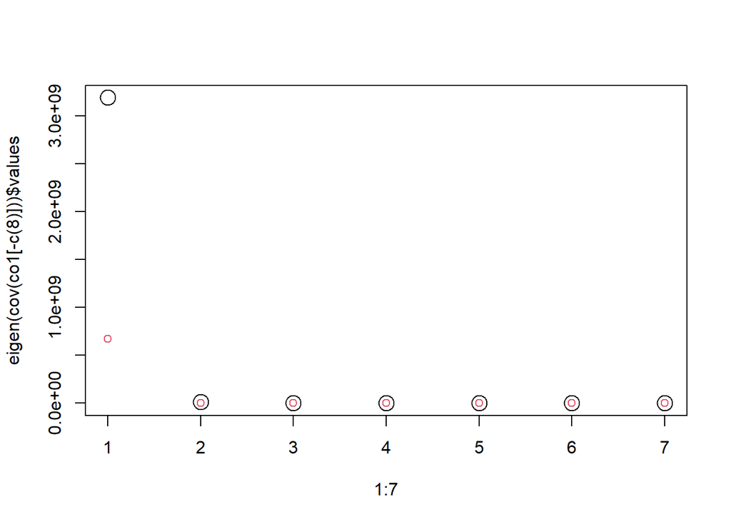

```r
plot(1:7, eigen(cov(co1[-c(8)]))$values, cex=2)
points(1:7, eigen(cov(co0[-c(8)]))$values, col=2)
```